# NHBE IAV Seurat Analysis

## Save/load Data For Downstream Analysis

```r
# saveRDS(NHBE_IAVWT, "seurat_objects_NHBE_IAVWT_processed.rds")
# NHBE_IAVWT <- readRDS(file="seurat_objects_NHBE_IAVWT_processed.rds")
```

### Visualize individual sample

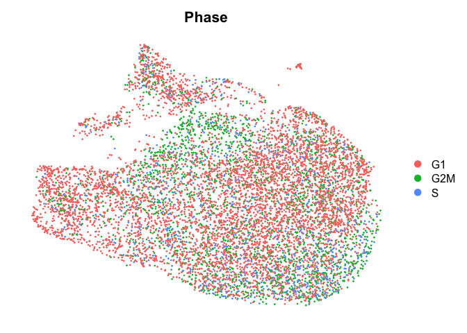

```r
p1 = DimPlot(NHBE_IAVWT, group.by = 'Phase', reduction = "umap",label=F)& NoAxes()

p2 = FeaturePlot(NHBE_IAVWT, features = c('percent.viral'), reduction = "umap",label=F, order = T,max.cutoff = 'q95')& NoAxes()

p3 = DimPlot(NHBE_IAVWT, label = TRUE,reduction = 'umap') & NoAxes() & NoLegend()

p4 = VlnPlot(NHBE_IAVWT, features = c(Vir), assay='SCT', ncol=3, pt.size = 0.0001)

p5 = FeaturePlot(NHBE_IAVWT, features = c('IFNL1','IFIT1',"HSPA1B","PR8-NS")) & NoAxes() & NoLegend()

p6 = DoHeatmap(NHBE_IAVWT,
          features = Vir,
          assay = 'RNA',
          slot = 'data')  # all viral expression below 0.8 is displayed as 0

p1
```

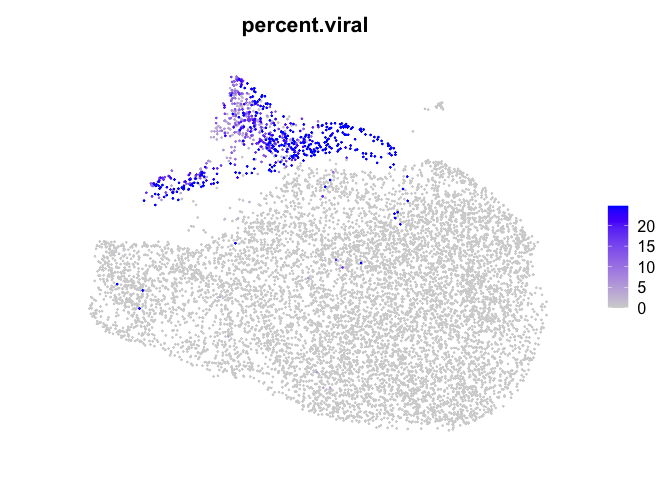

```r
p2
```

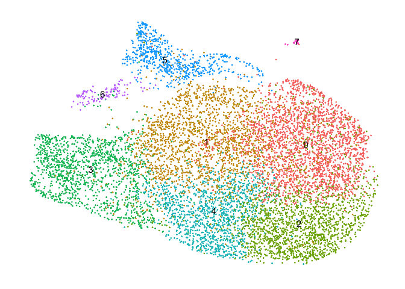

```r
p3
```

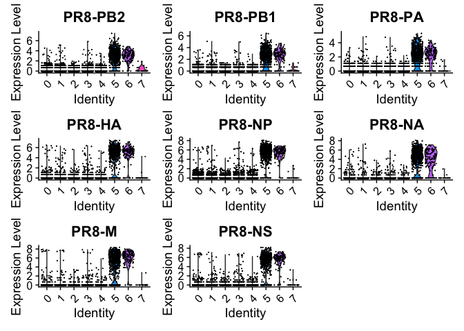

```r
p4
```

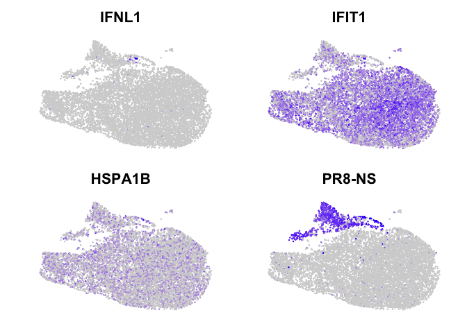

```r
p5
```

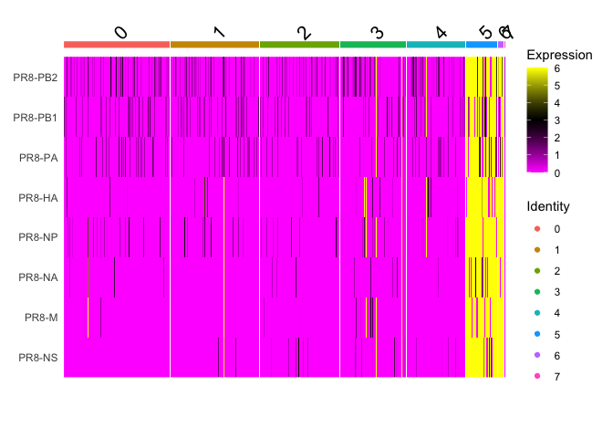

```r
p6
```

```r
ggsave(plot=p2,device = "pdf",filename =  "./saves/percent_viral.pdf", height = 4, width = 4)
```

### Add modular score for different host response

Using defined gene lists from bulk analysis

```r
gsea_ranked_ns1 = read.csv("gsea_ranked_ns1.csv")
gsea_ranked_wt = read.csv("gsea_ranked_wt.csv")
#
# gsea_ranked_ns1_sig = gsea_ranked_ns1[which(gsea_ranked_ns1$SCORE<(-1)),]
# gsea_ranked_wt_sig = gsea_ranked_wt[which(gsea_ranked_wt$SCORE<(-1)),]

gsea_ranked_ns1_sig = gsea_ranked_ns1[1:100,]
gsea_ranked_wt_sig = gsea_ranked_wt[1:100,]

gsea_ranked_ns1_sig=gsea_ranked_ns1_sig[which(!(gsea_ranked_ns1_sig$NAME %in% gsea_ranked_wt_sig$NAME)),]

gsea_ranked_wt_sig=gsea_ranked_wt_sig[which(!(gsea_ranked_wt_sig$NAME %in% gsea_ranked_ns1_sig$NAME)),]
```

```r
NHBE_IAVWT = AddModuleScore(NHBE_IAVWT, list(gsea_ranked_ns1_sig$NAME), assay = "SCT", name="NS1")
NHBE_IAVWT = AddModuleScore(NHBE_IAVWT, list(gsea_ranked_wt_sig$NAME), assay = "SCT", name="WT")
```

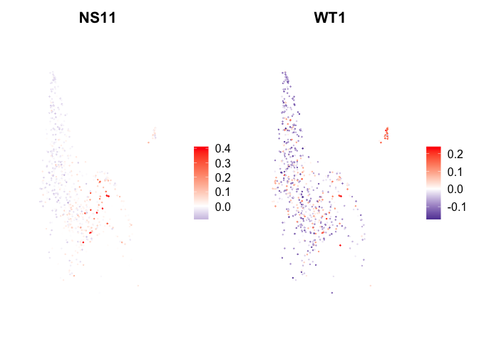

```r
NHBE_IAVWT_infected =  subset(x = NHBE_IAVWT, subset = (seurat_clusters == "5")|(seurat_clusters == "7"))
library(scales)
goi=c("NS11","WT1")
p= FeaturePlot(NHBE_IAVWT_infected, features = goi, max.cutoff = "q99", order=F, pt.size = 0.1) &
  scale_colour_gradient2(midpoint = 0,   low = ("navy"), mid = "white", high = ("red")) &
  NoAxes()
p
```

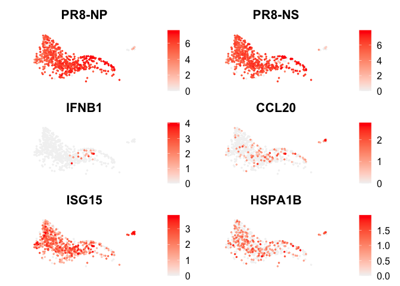

```r
ggsave(plot=p,device = "pdf",filename =  "./saves/GSEA_gene_score.pdf", height = 3, width = 6)


goi=c("PR8-NP","PR8-NS", "IFNB1","CCL20","ISG15","HSPA1B")
p= FeaturePlot(NHBE_IAVWT_infected, features = goi, max.cutoff = "q99", order=T, pt.size = 0.5) &
  scale_colour_gradient2(midpoint = 0,   low = ("navy"), mid = "grey95", high = ("red")) &
  NoAxes()
p
```

```r
ggsave(plot=p,device = "pdf",filename =  "./saves/example_expression.pdf", height = 10, width = 7)
```

### Now separate out only infected cells to define the NS1 bins

```r
normalized_cts=NHBE_IAVWT[["SCT"]]@counts
cell_meta=NHBE_IAVWT@meta.data
```

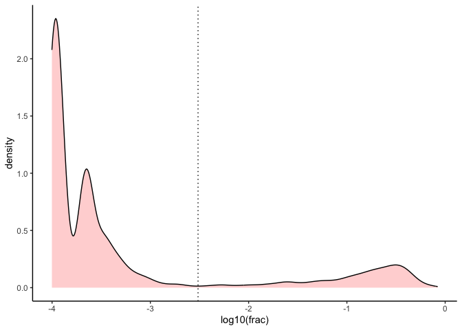

```r
frac_viral = colSums(normalized_cts[Vir,])/colSums(normalized_cts)
NHBE_IAVWT[["frac_viral"]]=frac_viral
d = density(log10(frac_viral))
cutoff_infected = optimize(approxfun(d$x,d$y),interval=c(-4,0))$minimum
# cutoff_infected = -1
frac_viral_df=data.frame(id=names(frac_viral),frac=frac_viral,label=cell_meta$orig.ident)

p = ggplot(frac_viral_df, aes(x=log10(frac))) +geom_density(alpha=0.2, fill="red")+
  geom_vline(aes(xintercept=(cutoff_infected)), linetype="dotted")+
  theme_classic()

p
```

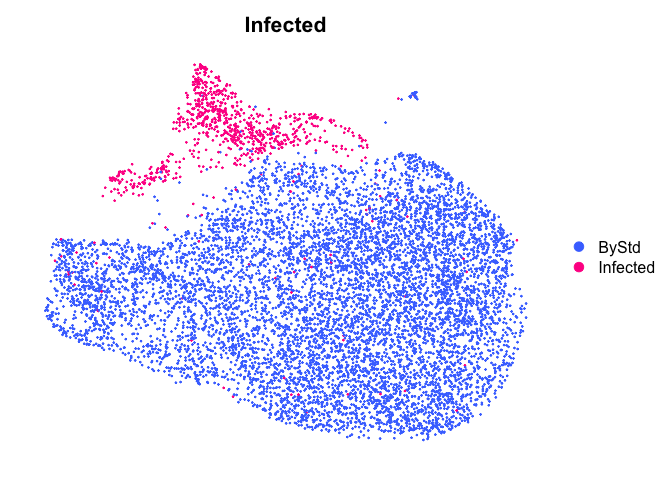

```r
ggsave(plot=p,device = "pdf",filename =  "./saves/viral_fraction.pdf", height = 4, width = 4)
Infected=names(which(log10(frac_viral)>cutoff_infected))
NHBE_IAVWT[["Infected"]] <- ifelse(colnames(NHBE_IAVWT) %in% Infected, "Infected", "ByStd")
p = DimPlot(NHBE_IAVWT, group.by = 'Infected', reduction = 'umap',
        cols=c('royalblue1','deeppink','darkgray')) & NoAxes()

p
```

```r
ggsave(plot=p, device = "pdf",filename =  "./saves/infected_cells.pdf", height = 4, width = 4)
```

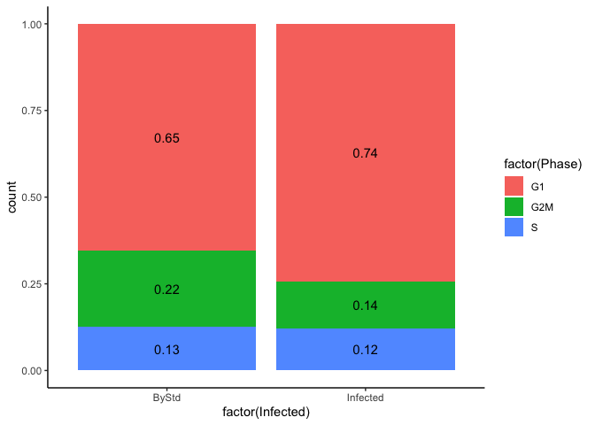

```r
cell_meta=NHBE_IAVWT@meta.data
p = ggplot(cell_meta, aes(x = factor(Infected), fill = factor(Phase))) +
geom_bar(position="fill") + geom_text(aes(label=signif(..count.. / tapply(..count.., ..x.., sum)[as.character(..x..)], digits=2)),stat="count",position=position_fill(vjust=0.5)) +
theme_classic()
p
```

```r
ggsave(plot=p, device = "pdf",filename =  "./saves/infected_cell_phase.pdf", height = 4, width = 4)
```

```r
infected_meta = cell_meta[which(cell_meta$Infected=="Infected"),]
infected_cts = normalized_cts[,rownames(infected_meta)]
```

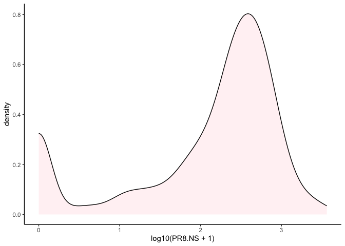

```r
expr_df = data.frame(id=rownames(infected_meta), ns1_resp=infected_meta$NS11, wt_resp=infected_meta$WT1 ,t(infected_cts))

ggplot(expr_df, aes(x=log10(`PR8.NS`+1))) +geom_density(alpha=0.2,fill="pink")+theme_classic()
```

```r
plot_mix_comps <- function(x, mu, sigma, lam) {
  lam * dnorm(x, mu, sigma)
}
```

```r
L10NS1 = log10(expr_df$PR8.NS+1)

# Find the local minimum for low NS1 expression
d = density(L10NS1)
cutoff_no_ns1 = optimize(approxfun(d$x,d$y),interval=c(0,1))$minimum

# Find the local minimum for mid/high NS1 expression. This is done by fitting bimodal normal distributions on the rest of the data, and the cutoff is the intersection between two distributions
x=L10NS1[L10NS1>cutoff_no_ns1]
mixmdl = normalmixEM(x,k=2)
```

```
## number of iterations= 131
```

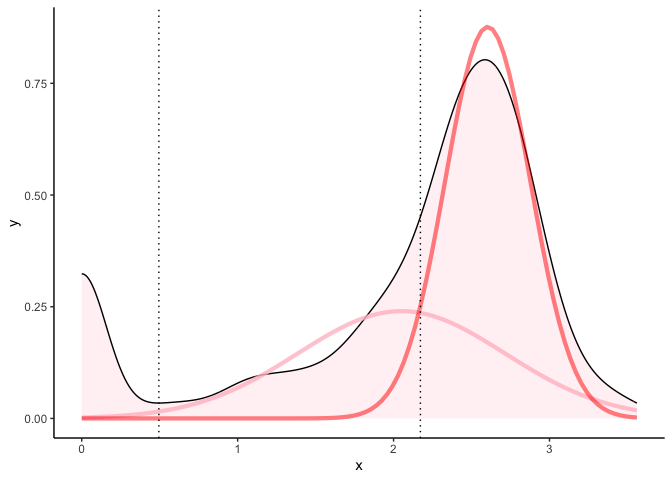

```r
plot_df=data.frame(x = mixmdl$x)

distributions.plot =ggplot() +
  geom_density(data=data.frame(x=L10NS1), aes(x), fill = "pink") +
  stat_function(data = plot_df, geom = "line", fun = plot_mix_comps, args = list(mixmdl$mu[1], mixmdl$sigma[1], lam = mixmdl$lambda[1]), colour = "red", lwd = 1.5) +
  stat_function(data = plot_df, geom = "line", fun = plot_mix_comps, args = list(mixmdl$mu[2], mixmdl$sigma[2], lam = mixmdl$lambda[2]), colour = "blue", lwd = 1.5) +
  theme_classic()

#extract coordinates of both lines from plot
line.df = data.frame(x = ggplot_build(distributions.plot)$data[[2]]$x,
                     red = ggplot_build(distributions.plot)$data[[2]]$y,
                     blue = ggplot_build(distributions.plot)$data[[3]]$y)

#find the minimal distance between lines along y axis
line.df$delta = line.df$red - line.df$blue

#find x coordinate for the minimal delta y
x_coord = line.df$x[which(diff(sign(diff((abs(line.df$delta))))) == 2)+1]

cutoff_mid_ns1 = x_coord[1]


# cutoff_mid_ns1 = 2.5

p = ggplot() +
  geom_density(data=data.frame(x=L10NS1), aes(x), fill = "pink", alpha=0.2) +
  stat_function(data = plot_df, geom = "line", fun = plot_mix_comps,
                args = list(mixmdl$mu[1], mixmdl$sigma[1], lam = mixmdl$lambda[1]),
                colour = "pink", alpha=0.8, lwd = 1.5) +
  stat_function(data = plot_df, geom = "line", fun = plot_mix_comps,
                args = list(mixmdl$mu[2], mixmdl$sigma[2], lam = mixmdl$lambda[2]),
                colour = "red", alpha=0.5, lwd = 1.5) +
  geom_vline(xintercept = c(cutoff_no_ns1, cutoff_mid_ns1), linetype="dotted") +
  theme_classic()

p
```

```r
ggsave(plot=p, device = "pdf",filename =  "./saves/ns1_cutoffs.pdf", height = 4, width = 4)
```

```r
expr_df$NS1Bin=rep("Low",nrow(expr_df))
expr_df$NS1Bin[which(log10(expr_df$`PR8.NS`+1)>=cutoff_no_ns1 & log10(expr_df$`PR8.NS`+1)<cutoff_mid_ns1)]="Mid"
expr_df$NS1Bin[which(log10(expr_df$`PR8.NS`)>=cutoff_mid_ns1)]="High"
expr_df$NS1Bin=factor(expr_df$NS1Bin, levels = c("Low","Mid","High"))
summary(expr_df$NS1Bin)
```

```
##  Low  Mid High
##  118  199  541
```

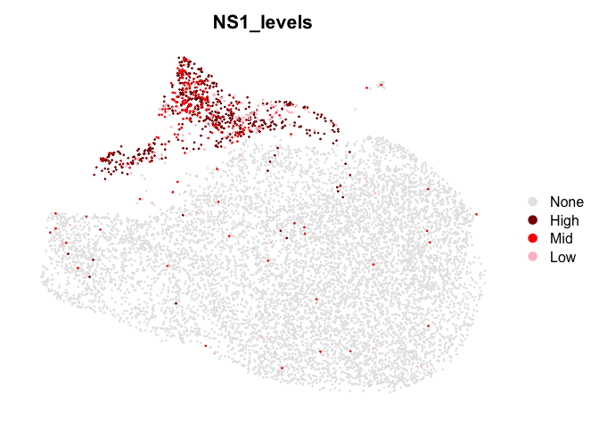

```r
NHBE_IAVWT[["NS1_levels"]] = "None"

NS1_HI = expr_df$id[which(expr_df$NS1Bin=="High")]
NS1_MID = expr_df$id[which(expr_df$NS1Bin=="Mid")]
NS1_LOW = expr_df$id[which(expr_df$NS1Bin=="Low")]

NHBE_IAVWT[["NS1_levels"]][NS1_HI,]="High"
NHBE_IAVWT[["NS1_levels"]][NS1_MID,]="Mid"
NHBE_IAVWT[["NS1_levels"]][NS1_LOW,]="Low"

NHBE_IAVWT$NS1_levels=factor(NHBE_IAVWT$NS1_levels, levels =c("High","Mid","Low",'None'))

p = DimPlot(NHBE_IAVWT, group.by = 'NS1_levels', reduction = 'umap',
        cols = rev(c("pink","red1","red4",'gray90')), order = c("Low","Mid","High",'None')) & NoAxes()
p
```

```r
ggsave(plot=p, device = "pdf",filename =  "./saves/ns1_levels.pdf", height = 6, width = 6)
```

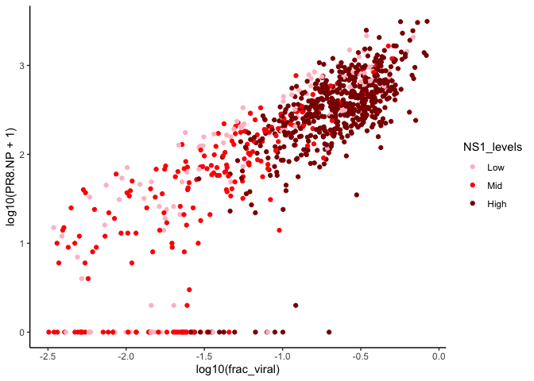

```r
NHBE_IAVWT_infected =  subset(x = NHBE_IAVWT, subset = Infected == "Infected")


cell_meta = NHBE_IAVWT_infected@meta.data
df = data.frame(cell_meta, t(NHBE_IAVWT_infected[["SCT"]]@counts[Vir,]))
df$NS1_levels=factor(df$NS1_levels, levels=c("Low","Mid","High"))

p = ggplot(df, aes(x=log10(frac_viral), y=log10(PR8.NP+1), color=NS1_levels)) +
  geom_point() +
  scale_color_manual(values = c("pink","red1","red4")) +
  theme_classic()
p
```

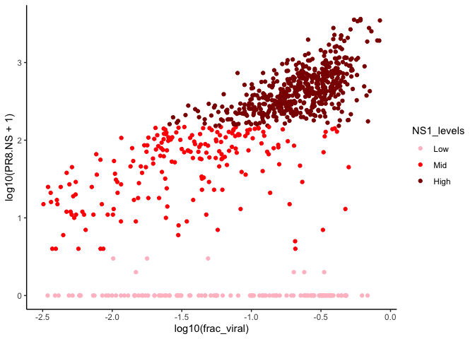

```r
ggsave(plot=p,device = "pdf",filename =  "./saves/viral_frac_v_NP.pdf", height = 4, width = 3)

p = ggplot(df, aes(x=log10(frac_viral), y=log10(PR8.NS+1), color=NS1_levels)) +
  geom_point() +
  scale_color_manual(values = c("pink","red1","red4")) +
  theme_classic()
p
```

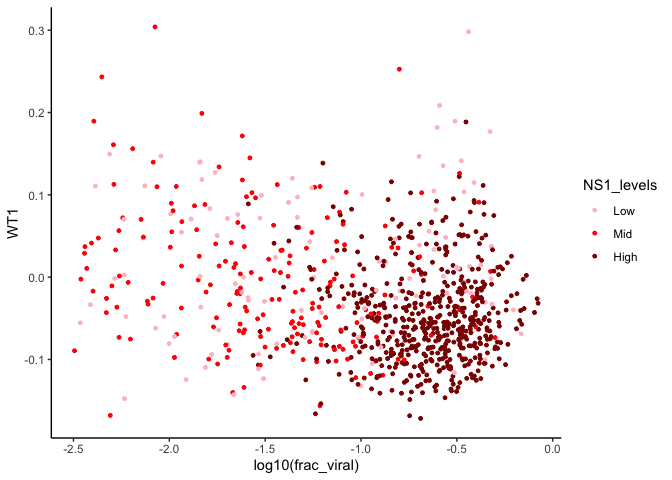

```r
ggsave(plot=p,device = "pdf",filename =  "./saves/viral_frac_v_NS.pdf", height = 4, width = 3)


p = ggplot(df, aes(x=log10(frac_viral), y=WT1, color=NS1_levels)) +
  geom_point(size=1) +
  scale_color_manual(values = c("pink","red1","red4")) +
  # geom_smooth(method=lm, se=TRUE,  size=1, alpha=0.5)+
  theme_classic()
p
```

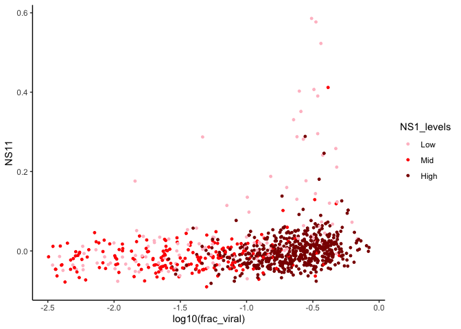

```r
ggsave(plot=p,device = "pdf",filename =  "./saves/viral_frac_v_WTresp.pdf", height = 4, width = 4)


p = ggplot(df, aes(x=log10(frac_viral), y=NS11, color=NS1_levels)) +
  geom_point(size=1) +
  scale_color_manual(values = c("pink","red1","red4")) +
  # geom_smooth(method=lm, se=TRUE,  size=1, alpha=0.5)+
  theme_classic()
p
```

```r
ggsave(plot=p,device = "pdf",filename =  "./saves/viral_frac_v_NS1resp.pdf", height = 4, width = 4)
```

### Examine marker gene expression given the current NS1 definition

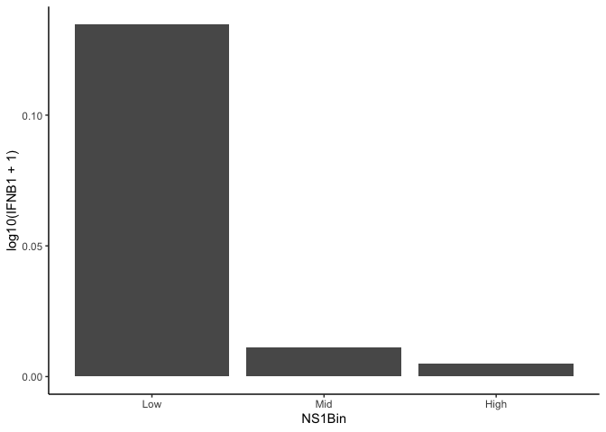

```r
ggplot(data=expr_df, aes(x=NS1Bin, y=log10(IFNB1+1))) +
  geom_bar(position = "dodge", stat = "summary", fun = "mean") +
  theme_classic()
```

```r
expr_all=data.frame(NHBE_IAVWT@meta.data, t(normalized_cts))
rownames(expr_all)=rownames(NHBE_IAVWT@meta.data)
```

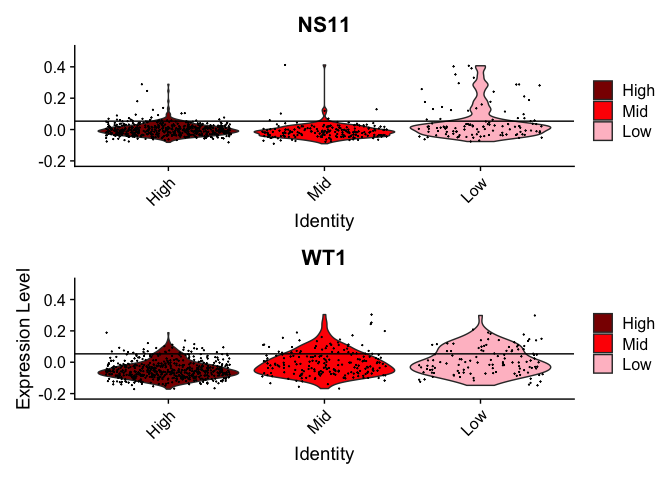

```r
NHBE_IAVWT_infected$NS1_levels=factor(NHBE_IAVWT_infected$NS1_levels, levels= c("High","Mid","Low"))

# ns1 response cutoff
cutoff_ns1_resp = quantile(cell_meta[which(cell_meta$NS1_levels=="High"),]$NS11,probs = 0.95)

# wt response cutoff
cutoff_wt_resp = quantile(cell_meta[which(cell_meta$NS1_levels=="High"),]$WT1,probs = 0.95)

p1 = VlnPlot(NHBE_IAVWT_infected, group.by = "NS1_levels", features = "NS11", cols = rev(c("pink","red1","red4"))) &
  ylim(c(-0.2,0.5)) &
  geom_hline(yintercept = cutoff_ns1_resp)
p2 = VlnPlot(NHBE_IAVWT_infected, group.by = "NS1_levels", features = "WT1", cols = rev(c("pink","red1","red4"))) &
  ylim(c(-0.2,0.5)) &
  geom_hline(yintercept = cutoff_ns1_resp)
ggsave(plot=p1+p2,device = "pdf",filename =  "./saves/violin_NS1_WT1_scores.pdf", height = 6, width = 3)
p1+p2
```

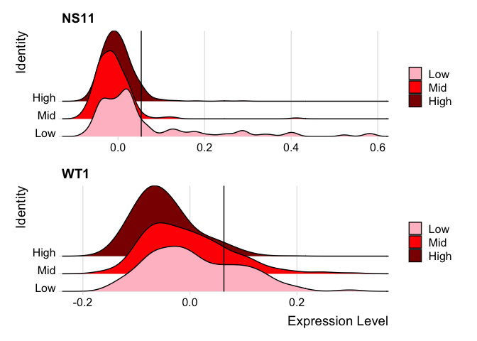

```r
NHBE_IAVWT_infected$NS1_levels=factor(NHBE_IAVWT_infected$NS1_levels, levels= rev(c("High","Mid","Low")))

p3 = RidgePlot(NHBE_IAVWT_infected, group.by = "NS1_levels", features = "NS11", cols = rev(c("red4","red1","pink"))) &
  geom_vline(xintercept = cutoff_ns1_resp)
p4 = RidgePlot(NHBE_IAVWT_infected, group.by = "NS1_levels", features = "WT1", cols = rev(c("red4","red1","pink"))) &
  geom_vline(xintercept = cutoff_wt_resp)
p3+p4
```

```r
ggsave(plot=p3+p4,device = "pdf",filename =  "./saves/ridge_NS1_WT1_scores.pdf", height = 6, width = 3)
```

### Instead of the generic IFN/ISG/UPR score, run the same comparison using GSEA results from bulk analysis

Here **NS1** means WT, NS-T vs dNS1 - genes can be silenced with any amount of NS1. And **WT** means WT vs NS-T, dNS1 - genes to be silenced by the largest amount of NS1

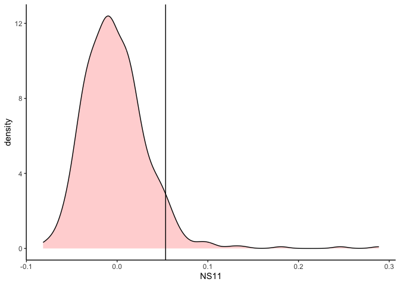

```r
cell_meta=NHBE_IAVWT@meta.data


ggplot(cell_meta[which(cell_meta$NS1_levels=="High"),], aes(x=NS11)) +
geom_density(alpha=0.2, fill="red") +
geom_vline(aes(xintercept=cutoff_ns1_resp)) +
theme_classic()
```

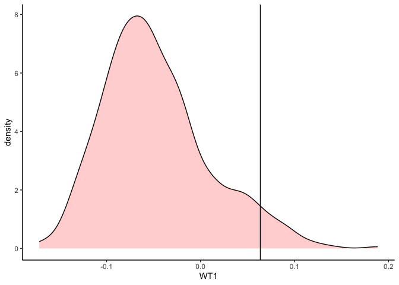

```r
ggplot(cell_meta[which(cell_meta$NS1_levels=="High"),], aes(x=WT1)) +
geom_density(alpha=0.2, fill="red")+
geom_vline(aes(xintercept=cutoff_wt_resp)) +
theme_classic()
```

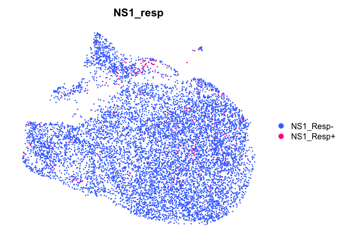

```r
NS1_resp_pos = rownames(cell_meta)[which(cell_meta$NS11>cutoff_ns1_resp)]
NHBE_IAVWT[["NS1_resp"]] <- ifelse(colnames(NHBE_IAVWT) %in% NS1_resp_pos, "NS1_Resp+", "NS1_Resp-")
DimPlot(NHBE_IAVWT, group.by = 'NS1_resp', reduction = 'umap',
        cols=c('royalblue1','deeppink','darkgray')) & NoAxes()
```

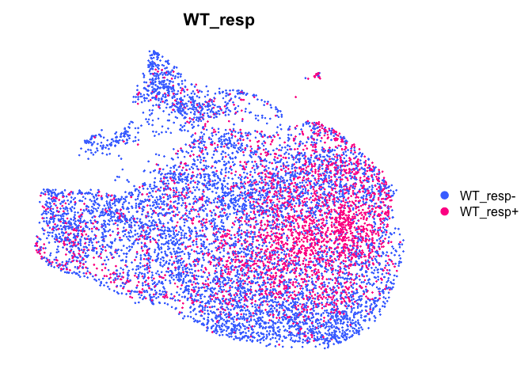

```r
WT_resp_pos = rownames(cell_meta)[which(cell_meta$WT1>cutoff_wt_resp)]
NHBE_IAVWT[["WT_resp"]] <- ifelse(colnames(NHBE_IAVWT) %in% WT_resp_pos, "WT_resp+", "WT_resp-")
DimPlot(NHBE_IAVWT, group.by = 'WT_resp', reduction = 'umap',
        cols=c('royalblue1','deeppink','darkgray')) & NoAxes()
```

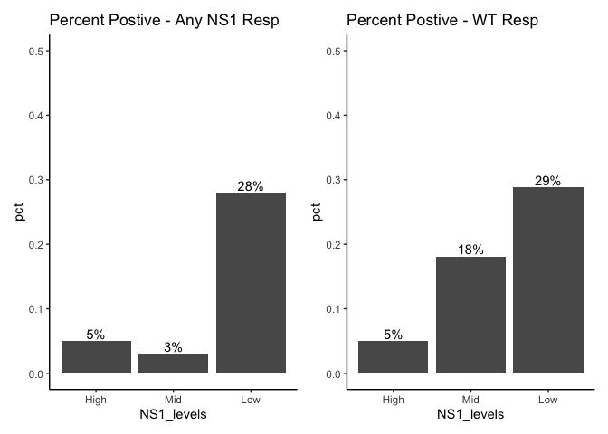

```r
cell_meta = NHBE_IAVWT@meta.data
cell_meta=cell_meta[which(cell_meta$Infected=="Infected"),]
# write.csv(infected_meta, 'infected_meta.csv')

p1 = cell_meta %>% mutate(NS1_levels= factor(NS1_levels,levels=c("High","Mid","Low"))) %>% group_by(NS1_levels) %>%
  count(NS1_resp) %>%
  mutate(pct = n/sum(n)) %>%
  filter(NS1_resp == "NS1_Resp+")%>%
  ggplot(aes(NS1_levels, pct))+
    geom_bar(stat = "identity") +
    geom_text(aes(label = scales::percent(pct)), vjust = -0.3) +
    ggtitle("Percent Postive - Any NS1 Resp") +
    ylim(c(0,0.5))+
    theme_classic()


p2 = cell_meta %>% mutate(NS1_levels= factor(NS1_levels,levels=c("High","Mid","Low"))) %>% group_by(NS1_levels) %>%
  count(WT_resp) %>%
  mutate(pct = n/sum(n)) %>%
  filter(WT_resp == "WT_resp+")%>%
  ggplot(aes(NS1_levels, pct))+
    geom_bar(stat = "identity") +
    geom_text(aes(label = scales::percent(pct)), vjust = -0.3) +
    ggtitle("Percent Postive - WT Resp") +
    ylim(c(0,0.5))+
    theme_classic()
p1 + p2
```

```r
ggsave(plot=p1 + p2,device = "pdf",filename =  "./saves/Percent_Postive_GSEA_Resp.pdf", height = 4, width = 8)
```

## Plot a heat map of NS1/WT genes with NS1 by bins

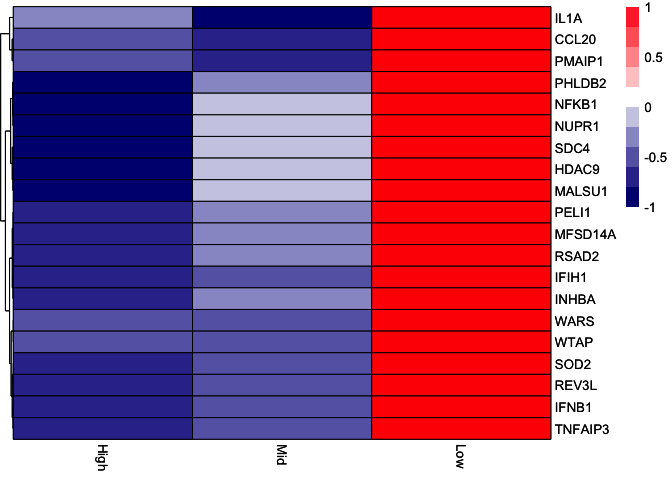

```r
gsea_ns1_sig_heatmap = gsea_ranked_ns1
gsea_wt_sig_heatmap = gsea_ranked_wt

myBreaks = seq(-1, 1, by = .2)
col=colorRampPalette(c("navy","white", "red"))(length(myBreaks))


# Any NS1
test=AverageExpression(NHBE_IAVWT,features = (gsea_ns1_sig_heatmap$NAME), assay="SCT",slot = "counts",group.by ="NS1_levels")[[1]]
test=data.frame(test)

test=test[which(rowSums(test[,1:3])>1),]
p = pheatmap::pheatmap(test[1:20,1:3],
                   show_colnames = T,
                   cluster_cols = F,
                   color = col,
                   scale="row",border_color = "black",
                    treeheight_row = 5,
                   breaks = myBreaks)
p
```

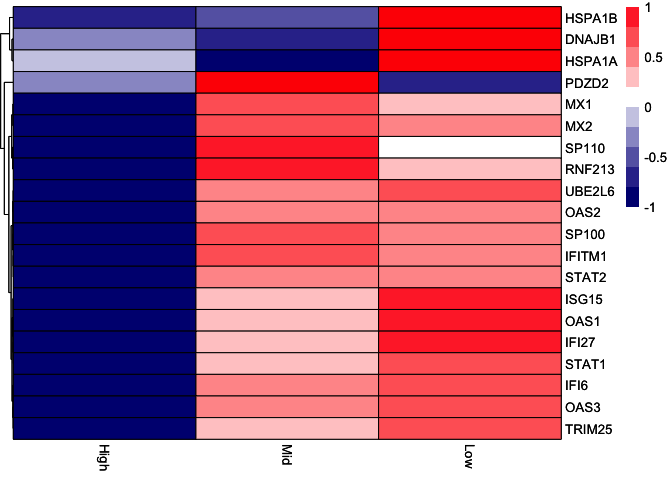

```r
ggsave(plot=p,device = "pdf",filename =  "./saves/heatmap_ns1resp.pdf", height = 4, width = 4)

# WT only
test=AverageExpression(NHBE_IAVWT,features = (gsea_wt_sig_heatmap$NAME), assay="SCT",slot = "counts",group.by ="NS1_levels")[[1]]
test=data.frame(test)

test=test[which(rowSums(test[,1:3])>1),]
p = pheatmap::pheatmap(test[1:20,1:3],
                   show_colnames = T,
                   cluster_cols = F,
                   color = col,
                   scale="row",border_color = "black",
                   treeheight_row = 5,
                   breaks = myBreaks)
p
```

```r
ggsave(plot=p,device = "pdf",filename =  "./saves/heatmap_wtresp.pdf", height = 4, width = 4)
```